[GitHub](https://github.com/agate-model/Agate.jl)[](https://github.com/agate-model/Agate.jl/blob/main/examples/predator_prey_palatability.jl)

# Predator-prey palatability

This example compares two ways of configuring predator-prey palatability in the Agate.jl-NiPiZD model. By default, the model computes the palatability matrix from allometric traits based on the preferred predator:prey size ratio (`optimum_predator_prey_ratio`, abbreviated here as `Vopt`). We will change this default value to use a different optimum. Additionally, we will show how the allometric calculation can be bypassed by supplying an explicit custom `palatability_matrix`.

After inspecting the resulting interaction matrices, each configuration is run in a 0D box-model setup so their tracer trajectories can be compared.

## Loading dependencies

The example uses Agate.jl, Oceananigans.jl, and OceanBioME.jl for the ecosystem simulation. CairoMakie.jl is used for plotting.

```julia
using Agate
using Agate.Introspection: interaction_matrix, tracer_names
using Agate.Library.Light
using OceanBioME
using OceanBioME: Biogeochemistry
using Oceananigans
using Oceananigans.Units
using CairoMakie
```

## Construct the ecosystem configurations

```julia
default_bgc = Agate.Models.NiPiZD.construct()
default_pal = interaction_matrix(default_bgc, :palatability)
```

The default configuration uses the model's allometric palatability calculation. By default, predators prefer prey that are 10 times smaller than themselves (`Vopt = 10`).

Instead, we will change that optimum to `Vopt = 5` for the two zooplankton consumers. Vector parameters can be overridden by plankton class name, so only the relevant entries need to be supplied. Omitted entries are filled from the model defaults.

```julia
vopt_bgc = Agate.Models.NiPiZD.construct(;
    parameters=(; optimum_predator_prey_ratio=(Z1=5.0, Z2=5.0))
)
vopt_pal = interaction_matrix(vopt_bgc, :palatability)
```

Another option is to provide the palatability matrix directly. This is useful for experiments where the intended interaction structure is known explicitly, rather than derived from size traits.

```julia
custom_bgc = Agate.Models.NiPiZD.construct(;
    palatability_matrix=[0.0 1.0; 1.0 0.0]
)
custom_pal = interaction_matrix(custom_bgc, :palatability)
```

## Helper for labelled matrix plots

```julia
function plot_matrix!(fig, position, table; title)
    mat = Matrix(table.matrix)
    nrows, ncols = size(mat)

    ax = Axis(
        fig[position...];
        title,
        xlabel=string(table.column_axis),
        ylabel=string(table.row_axis),
        xticks=(1:ncols, string.(table.columns)),
        yticks=(1:nrows, string.(table.rows)),
        yreversed=true,
        aspect=DataAspect(),
    )

    hm = heatmap!(ax, 1:ncols, 1:nrows, mat'; colorrange=(0, 1))

    for row in 1:nrows, col in 1:ncols
        text!(
            ax,
            col,
            row;
            text=string(round(mat[row, col]; digits=2)),
            align=(:center, :center),
            fontsize=12,
        )
    end

    return hm
end
```

## Compare the palatability matrices

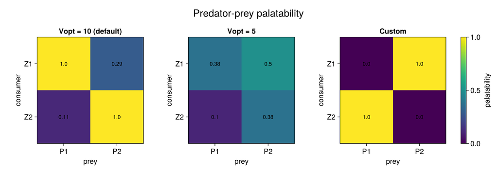

```julia
matrix_fig = Figure(; size=(1100, 380), fontsize=16)

hm_pal_default = plot_matrix!(matrix_fig, (1, 1), default_pal; title="Vopt = 10 (default)")

plot_matrix!(matrix_fig, (1, 2), vopt_pal; title="Vopt = 5")

plot_matrix!(matrix_fig, (1, 3), custom_pal; title="Custom")

Colorbar(matrix_fig[1, 4], hm_pal_default; label="palatability")

Label(matrix_fig[0, 1:4], "Predator-prey palatability"; fontsize=22)

save("predator_prey_palatability_matrices.png", matrix_fig; px_per_unit=1)

matrix_fig
```

## Run each configuration in a box model

```julia
function run_box_model(bgc, filename)
    light_attenuation = FunctionFieldPAR(; grid=BoxModelGrid())
    bgc_model = Biogeochemistry(bgc; light_attenuation)
    full_model = BoxModel(; biogeochemistry=bgc_model)

    set!(full_model; N=7.0, P1=0.01, Z1=0.01, P2=0.1, Z2=0.01, D=0.01)

    simulation = Simulation(full_model; Δt=240minutes, stop_time=1095days)

    simulation.output_writers[:fields] = JLD2Writer(
        full_model,
        full_model.fields;
        filename,
        schedule=TimeInterval(1day),
        overwrite_existing=true,
    )

    run!(simulation)

    return filename
end

default_filename = run_box_model(default_bgc, "predator_prey_palatability_default.jld2")
vopt_filename = run_box_model(vopt_bgc, "predator_prey_palatability_vopt5.jld2")
custom_filename = run_box_model(custom_bgc, "predator_prey_palatability_custom.jld2")
```

```
[ Info: Initializing simulation...
[ Info:     ... simulation initialization complete (816.592 ms)
[ Info: Executing initial time step...
[ Info:     ... initial time step complete (536.951 ms).
[ Info: Simulation is stopping after running for 4.721 seconds.
[ Info: Simulation time 1095 days equals or exceeds stop time 1095 days.
[ Info: Initializing simulation...
[ Info:     ... simulation initialization complete (1.214 ms)
[ Info: Executing initial time step...
[ Info:     ... initial time step complete (125.690 μs).
[ Info: Simulation is stopping after running for 3.326 seconds.
[ Info: Simulation time 1095 days equals or exceeds stop time 1095 days.
[ Info: Initializing simulation...
[ Info:     ... simulation initialization complete (1.186 ms)
[ Info: Executing initial time step...
[ Info:     ... initial time step complete (124.037 μs).
[ Info: Simulation is stopping after running for 3.332 seconds.
[ Info: Simulation time 1095 days equals or exceeds stop time 1095 days.
```

## Load the output time series

```julia
tracer_syms = tracer_names(default_bgc)

default_timeseries = (;
    (s => FieldTimeSeries(default_filename, string(s))[1, 1, 1, :] for s in tracer_syms)...
)

vopt_timeseries = (;
    (s => FieldTimeSeries(vopt_filename, string(s))[1, 1, 1, :] for s in tracer_syms)...
)

custom_timeseries = (;
    (s => FieldTimeSeries(custom_filename, string(s))[1, 1, 1, :] for s in tracer_syms)...
)

times = FieldTimeSeries(default_filename, string(first(tracer_syms))).times
```

## Compare the box-model output

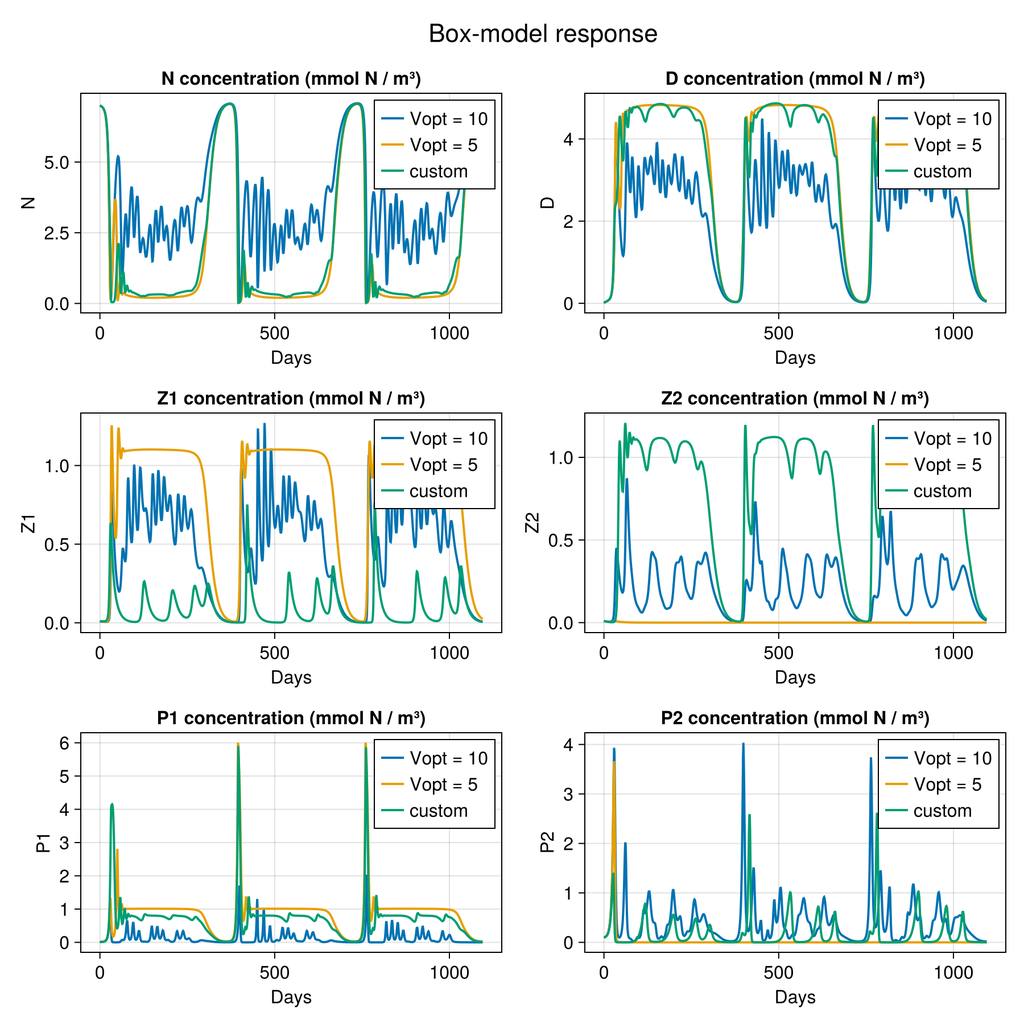

```julia
simulation_fig = Figure(; size=(900, 900), fontsize=16)

Label(simulation_fig[0, 1:2], "Box-model response"; fontsize=22)

for (idx, sym) in enumerate(tracer_syms)
    row = 1 + div(idx - 1, 2)
    col = 1 + mod(idx - 1, 2)

    ax = Axis(
        simulation_fig[row, col];
        ylabel=string(sym),
        xlabel="Days",
        title="$(sym) concentration (mmol N / m³)",
    )

    lines!(
        ax,
        times / day,
        getproperty(default_timeseries, sym);
        label="Vopt = 10",
        linewidth=2,
    )
    lines!(
        ax,
        times / day,
        getproperty(vopt_timeseries, sym);
        label="Vopt = 5",
        linewidth=2,
    )
    lines!(
        ax,
        times / day,
        getproperty(custom_timeseries, sym);
        label="custom",
        linewidth=2,
    )
    axislegend(ax; position=:rt)
end

save("predator_prey_palatability_simulation.png", simulation_fig; px_per_unit=1)

simulation_fig
```

*This page was generated using Literate.jl.*